# Day 3 Lecture

# R Markdown vs. scripts

Sweave: the original “reproducible document”, mix of LaTeX and R

R Markdown: one of the “cutting edge” formats, especially well-integrated into RStudio, that allows mixing of R code with text, document formatting, links, graphics, etc.

The following is a code chunk, and when `knitr()` is run on this document, it will display both the code and the output.

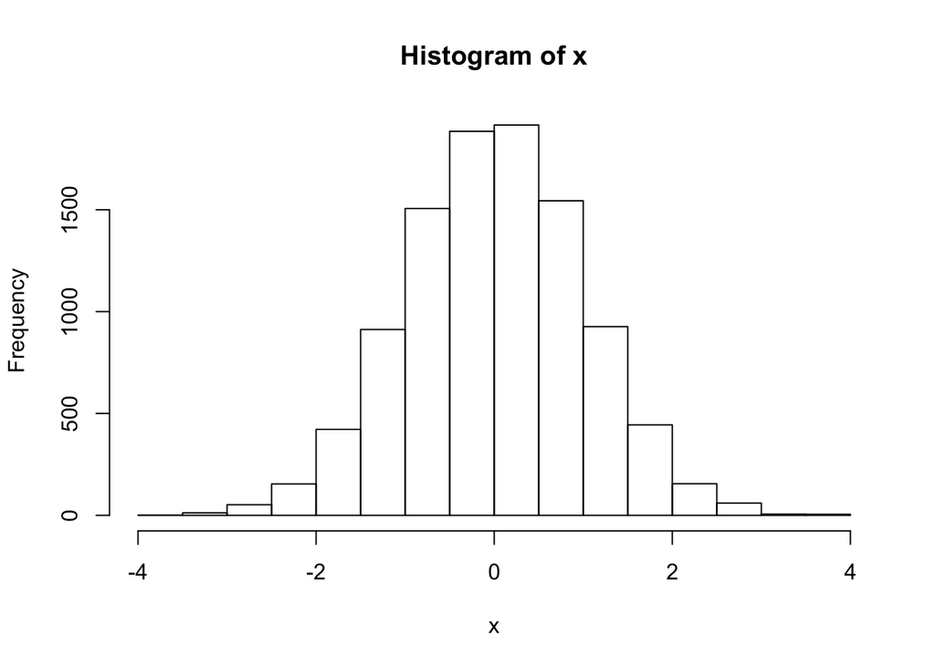

```r
x <- rnorm(10000)
hist(x)  # this is a histogram
```

```r
t.test(x)
```

```
##
##  One Sample t-test
##
## data:  x
## t = 1.1854, df = 9999, p-value = 0.2359
## alternative hypothesis: true mean is not equal to 0
## 95 percent confidence interval:
##  -0.007723047  0.031355040
## sample estimates:
## mean of x
##  0.011816
```

You can also insert “inline” results, like the following:

The mean of `x` is 0.011816.

More documentation on Markdown and R Markdown: Help > Markdown Quick Reference Help > RStudio Docs

# Reading and writing data/files

## Weird file types

Package for reading Excel data: `readxl`

Package for other stats packages (SPSS, SAS, Stata): `haven`

“Tidyverse” package for reading various kinds of data: `readr`

## “Reading” .RData

`save()` saves objects into a file `load()` puts objects in your workspace from an `.RData` file

## Look at the options!

```r
?read.table

mydata <- read.csv(filename, na.strings = c("NA", "N/A", "n/a", " ", "nuthin"))

?readLines
?scan
```

## Writing files

```r
?write.table # .csv, etc.
```

Catches - rownames!

```r
write.table(mydata, file = "outputfile.txt",
            sep = "\t",   # this makes the output tab-delimited
            row.names = FALSE)  # good for exporting data

write.csv(mydata, file = "outputfile.csv", row.names = FALSE) # good for writing CSVs
```

# Data types

- numeric
- logical
- character
- factor
- NA
- NULL
- others (e.g, “Date”)

## Numeric

- numbers!
- sometimes integers can differ from non-integers
- `as.numeric()` forces it to be a number (not integers)
- `1L` is an integer
- have mean, medians

## Logicals

- TRUE and FALSE
- if coerced to `as.numeric`, TRUE == 1, FALSE == 0
  - can take the mean of a logical vector
- Shortcuts: T and F
  - *DANGER*: T and F can be overwritten
- logical operators create logical vectors
  - `==`
  - `>`
  - `<`
  - `|` This is the “long bar”, meaning (inclusive) “or” (aka “pipe”)
  - `&` == “and”
  - `>=` greater or equal
  - `!` is NOT
  - `&&` and `||` for more specific programming situations

```r
3 < 4
```

```
## [1] TRUE
```

```r
sleep
```

```
##    extra group ID
## 1    0.7     1  1
## 2   -1.6     1  2
## 3   -0.2     1  3
## 4   -1.2     1  4
## 5   -0.1     1  5
## 6    3.4     1  6
## 7    3.7     1  7
## 8    0.8     1  8
## 9    0.0     1  9
## 10   2.0     1 10
## 11   1.9     2  1
## 12   0.8     2  2
## 13   1.1     2  3
## 14   0.1     2  4
## 15  -0.1     2  5
## 16   4.4     2  6
## 17   5.5     2  7
## 18   1.6     2  8
## 19   4.6     2  9
## 20   3.4     2 10
```

```r
sleep$extra < 0 | sleep$extra > 4
```

```
##  [1] FALSE  TRUE  TRUE  TRUE  TRUE FALSE FALSE FALSE FALSE FALSE FALSE
## [12] FALSE FALSE FALSE  TRUE  TRUE  TRUE FALSE  TRUE FALSE
```

```r
(sleep$extra < 0) & (sleep$extra > 4)
```

```
##  [1] FALSE FALSE FALSE FALSE FALSE FALSE FALSE FALSE FALSE FALSE FALSE
## [12] FALSE FALSE FALSE FALSE FALSE FALSE FALSE FALSE FALSE
```

```r
!sleep$extra < 0
```

```
##  [1]  TRUE FALSE FALSE FALSE FALSE  TRUE  TRUE  TRUE  TRUE  TRUE  TRUE
## [12]  TRUE  TRUE  TRUE FALSE  TRUE  TRUE  TRUE  TRUE  TRUE
```

```r
c(1, 2, 3, 4) < c(0, 3, 1, 5)
```

```
## [1] FALSE  TRUE FALSE  TRUE
```

```r
which(sleep$extra > 0)
```

```
##  [1]  1  6  7  8 10 11 12 13 14 16 17 18 19 20
```

```r
sleep$extra[sleep$extra > 0]
```

```
##  [1] 0.7 3.4 3.7 0.8 2.0 1.9 0.8 1.1 0.1 4.4 5.5 1.6 4.6 3.4
```

```r
iris[iris$Species == "setosa" | iris$Sepal.Length > 5, ]
```

```
##     Sepal.Length Sepal.Width Petal.Length Petal.Width    Species
## 1            5.1         3.5          1.4         0.2     setosa
## 2            4.9         3.0          1.4         0.2     setosa
## 3            4.7         3.2          1.3         0.2     setosa
## 4            4.6         3.1          1.5         0.2     setosa
## 5            5.0         3.6          1.4         0.2     setosa
## 6            5.4         3.9          1.7         0.4     setosa
## 7            4.6         3.4          1.4         0.3     setosa
## 8            5.0         3.4          1.5         0.2     setosa
## 9            4.4         2.9          1.4         0.2     setosa
## 10           4.9         3.1          1.5         0.1     setosa
## 11           5.4         3.7          1.5         0.2     setosa
## 12           4.8         3.4          1.6         0.2     setosa
## 13           4.8         3.0          1.4         0.1     setosa
## 14           4.3         3.0          1.1         0.1     setosa
```

[output cut: 132 more lines]

```r
wrong.way <- iris[iris$Species == c("setosa", "virginica"), ] # does not work like you want it to
nrow(wrong.way)
```

```
## [1] 50
```

```r
right.way <- iris[iris$Species %in% c("setosa", "virginica"), ]
nrow(right.way)
```

```
## [1] 100
```

```r
not.in <- iris[!iris$Species %in% c("setosa", "virginica"), ]
iris[iris$Species != "setosa", ]
```

```
##     Sepal.Length Sepal.Width Petal.Length Petal.Width    Species
## 51           7.0         3.2          4.7         1.4 versicolor
## 52           6.4         3.2          4.5         1.5 versicolor
## 53           6.9         3.1          4.9         1.5 versicolor
## 54           5.5         2.3          4.0         1.3 versicolor
## 55           6.5         2.8          4.6         1.5 versicolor
## 56           5.7         2.8          4.5         1.3 versicolor
## 57           6.3         3.3          4.7         1.6 versicolor
## 58           4.9         2.4          3.3         1.0 versicolor
## 59           6.6         2.9          4.6         1.3 versicolor
## 60           5.2         2.7          3.9         1.4 versicolor
## 61           5.0         2.0          3.5         1.0 versicolor
## 62           5.9         3.0          4.2         1.5 versicolor
## 63           6.0         2.2          4.0         1.0 versicolor
## 64           6.1         2.9          4.7         1.4 versicolor
```

[output cut: 86 more lines]

```r
iris[!iris$Species == "setosa", ]
```

```
##     Sepal.Length Sepal.Width Petal.Length Petal.Width    Species
## 51           7.0         3.2          4.7         1.4 versicolor
## 52           6.4         3.2          4.5         1.5 versicolor
## 53           6.9         3.1          4.9         1.5 versicolor
## 54           5.5         2.3          4.0         1.3 versicolor
## 55           6.5         2.8          4.6         1.5 versicolor
## 56           5.7         2.8          4.5         1.3 versicolor
## 57           6.3         3.3          4.7         1.6 versicolor
## 58           4.9         2.4          3.3         1.0 versicolor
## 59           6.6         2.9          4.6         1.3 versicolor
## 60           5.2         2.7          3.9         1.4 versicolor
## 61           5.0         2.0          3.5         1.0 versicolor
## 62           5.9         3.0          4.2         1.5 versicolor
## 63           6.0         2.2          4.0         1.0 versicolor
## 64           6.1         2.9          4.7         1.4 versicolor
```

[output cut: 86 more lines]

## Characters

- `as.character()` converts to characters
- more primitive than factors
- can manipulate with regular expressions, other text functions

## Factors

- Actually numbers under the hood
- Act like numbers + labels
- VERY useful for many kinds of analyses
- if a column is a *property* of data (not a measure itself), factors are usually best
  - groupings = good as factors
  - conditions = good as factors
- if a column is *data*, maybe consider keeping it a string
  - free response answers = bad as factors
- `as.factor()` coerces to a factor
- `factor()` creates a factor
- factors have *levels*: categories
- `stringsAsFactors` : option for how to read in character vectors
  - = FALSE if you don’t want to read in characters as factors

```r
scott <- read.csv("../scottdata/CognitionPaperFinalData.csv")
summary(scott$Merged)
```

```
##   Merged Unmerged
##       56      578
```

```r
summary(as.character(scott$Merged))
```

```
##    Length     Class      Mode
##       634 character character
```

```r
levels(scott$Merged)
```

```
## [1] "Merged"   "Unmerged"
```

```r
levels(scott$Merged) <- c("Unmerged", "Merged") # only changing the labels
levels(scott$Merged)
```

```
## [1] "Unmerged" "Merged"
```

```r
levels(scott$Merged) <- c("Merged", "Unmerged") # only changing the labels
scott$Merged <- factor(scott$Merged, levels = c("Unmerged", "Merged"))

# relevel()
# takes the level specified and moves it to the front
scott$Merged <- relevel(scott$Merged, "Merged")
summary(scott$Merged)
```

```
##   Merged Unmerged
##       56      578
```

```r
summary(scott$Corpus)
```

```
##  Am  Du  Fr  Ge  HK  Ko  RP  Sl  Sp
## 247  36  29  35  22  70  98  72  25
```

```r
scott$Corpus <- relevel(scott$Corpus, "RP")
summary(scott$Corpus)
```

```
##  RP  Am  Du  Fr  Ge  HK  Ko  Sl  Sp
##  98 247  36  29  35  22  70  72  25
```

```r
# reorder()
```

## Data manipulation excursion

### Creating (simple) new columns

```r
mysleep <- sleep
mysleep
```

```
##    extra group ID
## 1    0.7     1  1
## 2   -1.6     1  2
## 3   -0.2     1  3
## 4   -1.2     1  4
## 5   -0.1     1  5
## 6    3.4     1  6
## 7    3.7     1  7
## 8    0.8     1  8
## 9    0.0     1  9
## 10   2.0     1 10
## 11   1.9     2  1
## 12   0.8     2  2
## 13   1.1     2  3
## 14   0.1     2  4
## 15  -0.1     2  5
## 16   4.4     2  6
## 17   5.5     2  7
## 18   1.6     2  8
## 19   4.6     2  9
## 20   3.4     2 10
```

```r
mysleep$Study <- "Study1"
mysleep$noise <- rnorm(20)
mysleep
```

```
##    extra group ID  Study       noise
## 1    0.7     1  1 Study1 -0.26543290
## 2   -1.6     1  2 Study1 -0.55141761
## 3   -0.2     1  3 Study1 -1.29748813
## 4   -1.2     1  4 Study1 -0.81761832
## 5   -0.1     1  5 Study1  1.66501413
## 6    3.4     1  6 Study1 -0.03419810
## 7    3.7     1  7 Study1  0.95121442
## 8    0.8     1  8 Study1  0.33050815
## 9    0.0     1  9 Study1  0.25664392
## 10   2.0     1 10 Study1 -0.01297789
## 11   1.9     2  1 Study1 -0.48219391
## 12   0.8     2  2 Study1 -0.62581009
## 13   1.1     2  3 Study1 -0.39198643
## 14   0.1     2  4 Study1  0.93928201
## 15  -0.1     2  5 Study1 -2.14986062
## 16   4.4     2  6 Study1  0.16965318
## 17   5.5     2  7 Study1 -1.16294848
## 18   1.6     2  8 Study1 -0.50186226
## 19   4.6     2  9 Study1  0.94414097
## 20   3.4     2 10 Study1  0.24247565
```

```r
mysleep$Gender <- c("Male", "Female") # recycling
mysleep
```

```
##    extra group ID  Study       noise Gender
## 1    0.7     1  1 Study1 -0.26543290   Male
## 2   -1.6     1  2 Study1 -0.55141761 Female
## 3   -0.2     1  3 Study1 -1.29748813   Male
## 4   -1.2     1  4 Study1 -0.81761832 Female
## 5   -0.1     1  5 Study1  1.66501413   Male
## 6    3.4     1  6 Study1 -0.03419810 Female
## 7    3.7     1  7 Study1  0.95121442   Male
## 8    0.8     1  8 Study1  0.33050815 Female
## 9    0.0     1  9 Study1  0.25664392   Male
## 10   2.0     1 10 Study1 -0.01297789 Female
## 11   1.9     2  1 Study1 -0.48219391   Male
## 12   0.8     2  2 Study1 -0.62581009 Female
## 13   1.1     2  3 Study1 -0.39198643   Male
## 14   0.1     2  4 Study1  0.93928201 Female
## 15  -0.1     2  5 Study1 -2.14986062   Male
## 16   4.4     2  6 Study1  0.16965318 Female
## 17   5.5     2  7 Study1 -1.16294848   Male
## 18   1.6     2  8 Study1 -0.50186226 Female
## 19   4.6     2  9 Study1  0.94414097   Male
## 20   3.4     2 10 Study1  0.24247565 Female
```

```r
mysleep$Gender <- rep(c(rep("Male", 5), rep("Female", 5)), 2)
mysleep
```

```
##    extra group ID  Study       noise Gender
## 1    0.7     1  1 Study1 -0.26543290   Male
## 2   -1.6     1  2 Study1 -0.55141761   Male
## 3   -0.2     1  3 Study1 -1.29748813   Male
## 4   -1.2     1  4 Study1 -0.81761832   Male
## 5   -0.1     1  5 Study1  1.66501413   Male
## 6    3.4     1  6 Study1 -0.03419810 Female
## 7    3.7     1  7 Study1  0.95121442 Female
## 8    0.8     1  8 Study1  0.33050815 Female
## 9    0.0     1  9 Study1  0.25664392 Female
## 10   2.0     1 10 Study1 -0.01297789 Female
## 11   1.9     2  1 Study1 -0.48219391   Male
## 12   0.8     2  2 Study1 -0.62581009   Male
## 13   1.1     2  3 Study1 -0.39198643   Male
## 14   0.1     2  4 Study1  0.93928201   Male
## 15  -0.1     2  5 Study1 -2.14986062   Male
## 16   4.4     2  6 Study1  0.16965318 Female
## 17   5.5     2  7 Study1 -1.16294848 Female
## 18   1.6     2  8 Study1 -0.50186226 Female
## 19   4.6     2  9 Study1  0.94414097 Female
## 20   3.4     2 10 Study1  0.24247565 Female
```

```r
mysleep$direction[mysleep$extra >= 0] <- "positive"
mysleep$direction[mysleep$extra < 0] <- "negative"
mysleep$direction <- factor(mysleep$direction, levels = c("positive", "negative"))
summary(mysleep)
```

```
##      extra        group        ID       Study               noise
##  Min.   :-1.600   1:10   1      :2   Length:20          Min.   :-2.1499
##  1st Qu.:-0.025   2:10   2      :2   Class :character   1st Qu.:-0.5700
##  Median : 0.950          3      :2   Mode  :character   Median :-0.1498
##  Mean   : 1.540          4      :2                      Mean   :-0.1397
##  3rd Qu.: 3.400          5      :2                      3rd Qu.: 0.2751
##  Max.   : 5.500          6      :2                      Max.   : 1.6650
##                          (Other):8
##     Gender             direction
##  Length:20          positive:15
##  Class :character   negative: 5
##  Mode  :character
##
##
##
##
```

### Using xtabs() to check coding/cross-tabs

```r
xtabs(~ extra + direction, mysleep)
```

```
##       direction
## extra  positive negative
##   -1.6        0        1
##   -1.2        0        1
##   -0.2        0        1
##   -0.1        0        2
##   0           1        0
##   0.1         1        0
##   0.7         1        0
##   0.8         2        0
##   1.1         1        0
##   1.6         1        0
##   1.9         1        0
##   2           1        0
##   3.4         2        0
##   3.7         1        0
##   4.4         1        0
##   4.6         1        0
##   5.5         1        0
```

### Working with factors

```r
summary(scott)
```

```
##      Corpus          System         Pair       Contextual        Features
##  Am     :247   RP_CC    : 54   mn     :  8   Min.   :0.0000   Min.   :1
##  RP     : 98   Slovak_CC: 54   bm     :  6   1st Qu.:0.0000   1st Qu.:1
##  Sl     : 72   AE_CCons : 53   ei     :  6   Median :0.0000   Median :1
##  Ko     : 70   AE_td_e  : 50   pt     :  6   Mean   :0.3659   Mean   :1
##  Du     : 36   AE_VV    : 48   dn     :  5   3rd Qu.:1.0000   3rd Qu.:1
##  Ge     : 35   AE_VV_l  : 48   dt     :  5   Max.   :1.0000   Max.   :1
##  (Other): 76   (Other)  :327   (Other):598
##       Merged     AllMinPairs     BetweenMinPairs   WithinMinPairs
##  Merged  : 56   Min.   :   0.0   Min.   :   0.00   Min.   :   0.0
##  Unmerged:578   1st Qu.:   7.0   1st Qu.:   3.00   1st Qu.:   4.0
##                 Median :  59.0   Median :  25.00   Median :  30.0
##                 Mean   : 217.8   Mean   :  84.03   Mean   : 133.8
##                 3rd Qu.: 242.5   3rd Qu.:  99.75   3rd Qu.: 120.0
##                 Max.   :4628.0   Max.   :1436.00   Max.   :4486.0
##
##    AllEntropy        WithinEntropy         SegEntropy
##  Min.   :0.000e+00   Min.   :0.000e+00   Min.   :-0.0071455
##  1st Qu.:6.775e-06   1st Qu.:3.768e-06   1st Qu.: 0.0001305
##  Median :7.965e-05   Median :4.295e-05   Median : 0.0027451
##  Mean   :3.802e-04   Mean   :2.611e-04   Mean   : 0.0048715
##  3rd Qu.:3.937e-04   3rd Qu.:2.276e-04   3rd Qu.: 0.0076137
##  Max.   :2.109e-02   Max.   :2.072e-02   Max.   : 0.0371797
##
##  BiphoneEntropy          HiSegTok            LoSegTok
##  Min.   :-0.0091012   Min.   :0.0008174   Min.   :0.0000519
##  1st Qu.: 0.0002115   1st Qu.:0.0159757   1st Qu.:0.0029755
##  Median : 0.0019142   Median :0.0258700   Median :0.0080784
##  Mean   : 0.0041036   Mean   :0.0313976   Mean   :0.0122289
##  3rd Qu.: 0.0061909   3rd Qu.:0.0381062   3rd Qu.:0.0182902
##  Max.   : 0.0384248   Max.   :0.0915369   Max.   :0.0803203
##
##    HiSegType           LoSegType
##  Min.   :0.0008215   Min.   :0.0001287
##  1st Qu.:0.0130253   1st Qu.:0.0020678
##  Median :0.0253931   Median :0.0080152
##  Mean   :0.0299453   Mean   :0.0122549
##  3rd Qu.:0.0385659   3rd Qu.:0.0157192
##  Max.   :0.1070315   Max.   :0.0828637
##
```

```r
summary(scott$Corpus)
```

```
##  RP  Am  Du  Fr  Ge  HK  Ko  Sl  Sp
##  98 247  36  29  35  22  70  72  25
```

```r
scott$Corpus.full <- scott$Corpus
levels(scott$Corpus.full) <- c("American English", "Dutch", "French", "German", "Cantonese", "Korean", "British English", "Slovakian", "Spanish")
summary(scott$Corpus.full)
```

```
## American English            Dutch           French           German
##               98              247               36               29
##        Cantonese           Korean  British English        Slovakian
##               35               22               70               72
##          Spanish
##               25
```

```r
xtabs(~ Corpus + Corpus.full, scott)
```

```
##       Corpus.full
## Corpus American English Dutch French German Cantonese Korean
##     RP               98     0      0      0         0      0
##     Am                0   247      0      0         0      0
##     Du                0     0     36      0         0      0
##     Fr                0     0      0     29         0      0
##     Ge                0     0      0      0        35      0
##     HK                0     0      0      0         0     22
##     Ko                0     0      0      0         0      0
##     Sl                0     0      0      0         0      0
##     Sp                0     0      0      0         0      0
##       Corpus.full
## Corpus British English Slovakian Spanish
##     RP               0         0       0
##     Am               0         0       0
##     Du               0         0       0
##     Fr               0         0       0
##     Ge               0         0       0
##     HK               0         0       0
##     Ko              70         0       0
##     Sl               0        72       0
##     Sp               0         0      25
```

```r
summary(relevel(scott$Corpus.full, "British English"))
```

```
##  British English American English            Dutch           French
##               70               98              247               36
##           German        Cantonese           Korean        Slovakian
##               29               35               22               72
##          Spanish
##               25
```

```r
summary(scott$Merged)
```

```
##   Merged Unmerged
##       56      578
```

```r
summary(relevel(scott$Merged, "Unmerged"))
```

```
## Unmerged   Merged
##      578       56
```

```r
scott$MergedOrder[scott$Merged == "Unmerged"] <- 1
scott$MergedOrder[scott$Merged == "Merged"] <- 2

xtabs(~ Merged + MergedOrder, scott)
```

```
##           MergedOrder
## Merged       1   2
##   Merged     0  56
##   Unmerged 578   0
```

```r
summary(scott$Merged)
```

```
##   Merged Unmerged
##       56      578
```

```r
summary(reorder(scott$Merged, scott$MergedOrder))
```

```
## Unmerged   Merged
##      578       56
```

```r
summary(scott$Merged)
```

```
##   Merged Unmerged
##       56      578
```

```r
summary(factor(scott$Merged, levels = c("Unmerged", "Merged")))
```

```
## Unmerged   Merged
##      578       56
```

## NA and NULL (and others)

- `NA` mean “missing value” or “missing data”
- `NULL` means “nothing”, the absence of something
- `Inf` and `-Inf`
- `NaN`

Handling NAs - can be a a huge pain - sometimes `na.rm = TRUE` (like for `mean()`)

```r
x <- c(1, 2, NA, 4, 68)
mean(x)
```

```
## [1] NA
```

```r
mean(x, na.rm = TRUE)
```

```
## [1] 18.75
```

```r
x == NA
```

```
## [1] NA NA NA NA NA
```

```r
is.na(x)
```

```
## [1] FALSE FALSE  TRUE FALSE FALSE
```

```r
!is.na(x)
```

```
## [1]  TRUE  TRUE FALSE  TRUE  TRUE
```

- sometimes it’s other stuff
- `cor()` use = “pairwise.complete.obs”
- no universal “deal with NAs” argument

# More subsetting

## Basics

```r
sleep
```

```
##    extra group ID
## 1    0.7     1  1
## 2   -1.6     1  2
## 3   -0.2     1  3
## 4   -1.2     1  4
## 5   -0.1     1  5
## 6    3.4     1  6
## 7    3.7     1  7
## 8    0.8     1  8
## 9    0.0     1  9
## 10   2.0     1 10
## 11   1.9     2  1
## 12   0.8     2  2
## 13   1.1     2  3
## 14   0.1     2  4
## 15  -0.1     2  5
## 16   4.4     2  6
## 17   5.5     2  7
## 18   1.6     2  8
## 19   4.6     2  9
## 20   3.4     2 10
```

```r
sleep[sleep$group == 1, ]
```

```
##    extra group ID
## 1    0.7     1  1
## 2   -1.6     1  2
## 3   -0.2     1  3
## 4   -1.2     1  4
## 5   -0.1     1  5
## 6    3.4     1  6
## 7    3.7     1  7
## 8    0.8     1  8
## 9    0.0     1  9
## 10   2.0     1 10
```

```r
sleep$group == 1
```

```
##  [1]  TRUE  TRUE  TRUE  TRUE  TRUE  TRUE  TRUE  TRUE  TRUE  TRUE FALSE
## [12] FALSE FALSE FALSE FALSE FALSE FALSE FALSE FALSE FALSE
```

```r
sleep[which(sleep$group == 1), ]
```

```
##    extra group ID
## 1    0.7     1  1
## 2   -1.6     1  2
## 3   -0.2     1  3
## 4   -1.2     1  4
## 5   -0.1     1  5
## 6    3.4     1  6
## 7    3.7     1  7
## 8    0.8     1  8
## 9    0.0     1  9
## 10   2.0     1 10
```

```r
which(sleep$group == 1)
```

```
##  [1]  1  2  3  4  5  6  7  8  9 10
```

```r
sleep[sleep$group == 1 & sleep$extra > 0, ]
```

```
##    extra group ID
## 1    0.7     1  1
## 6    3.4     1  6
## 7    3.7     1  7
## 8    0.8     1  8
## 10   2.0     1 10
```

```r
sleep[sleep$group == 1 | sleep$extra > 0, ]
```

```
##    extra group ID
## 1    0.7     1  1
## 2   -1.6     1  2
## 3   -0.2     1  3
## 4   -1.2     1  4
## 5   -0.1     1  5
## 6    3.4     1  6
## 7    3.7     1  7
## 8    0.8     1  8
## 9    0.0     1  9
## 10   2.0     1 10
## 11   1.9     2  1
## 12   0.8     2  2
## 13   1.1     2  3
## 14   0.1     2  4
## 16   4.4     2  6
## 17   5.5     2  7
## 18   1.6     2  8
## 19   4.6     2  9
## 20   3.4     2 10
```

```r
# "where"
sleep[!sleep$group == 1, ]
```

```
##    extra group ID
## 11   1.9     2  1
## 12   0.8     2  2
## 13   1.1     2  3
## 14   0.1     2  4
## 15  -0.1     2  5
## 16   4.4     2  6
## 17   5.5     2  7
## 18   1.6     2  8
## 19   4.6     2  9
## 20   3.4     2 10
```

```r
sleep[sleep$ID == c(1, 3, 4, 6), ]  # DOESN'T WORK
```

```
##    extra group ID
## 1    0.7     1  1
## 16   4.4     2  6
```

```r
sleep[sleep$ID %in% c(1, 3, 4, 6), ]
```

```
##    extra group ID
## 1    0.7     1  1
## 3   -0.2     1  3
## 4   -1.2     1  4
## 6    3.4     1  6
## 11   1.9     2  1
## 13   1.1     2  3
## 14   0.1     2  4
## 16   4.4     2  6
```

```r
sleep$ID %in% c(1, 3, 4, 6)
```

```
##  [1]  TRUE FALSE  TRUE  TRUE FALSE  TRUE FALSE FALSE FALSE FALSE  TRUE
## [12] FALSE  TRUE  TRUE FALSE  TRUE FALSE FALSE FALSE FALSE
```

```r
sleep[!sleep$ID %in% c(1, 3, 4, 6), ]  # "not in"
```

```
##    extra group ID
## 2   -1.6     1  2
## 5   -0.1     1  5
## 7    3.7     1  7
## 8    0.8     1  8
## 9    0.0     1  9
## 10   2.0     1 10
## 12   0.8     2  2
## 15  -0.1     2  5
## 17   5.5     2  7
## 18   1.6     2  8
## 19   4.6     2  9
## 20   3.4     2 10
```

```r
# ?subset  # check Warning
# dplyr is better (IMHO)
# we will get to dplyr package tomorrow
```

# Combining data sets

## Combining data frame objects

### `rbind()` and `cbind()`

- rbind
  - glues rows on top of each other
  - expects same columns
  - new and improved `bind_rows()` in `dplyr` package
- cbind
  - glues columns next to each other
  - need to be the same length

```r
sleep1 <- sleep[sleep$group == 1,  ]
sleep2 <- sleep[sleep$group == 2,  ]
sleep1
```

```
##    extra group ID
## 1    0.7     1  1
## 2   -1.6     1  2
## 3   -0.2     1  3
## 4   -1.2     1  4
## 5   -0.1     1  5
## 6    3.4     1  6
## 7    3.7     1  7
## 8    0.8     1  8
## 9    0.0     1  9
## 10   2.0     1 10
```

```r
sleep2
```

```
##    extra group ID
## 11   1.9     2  1
## 12   0.8     2  2
## 13   1.1     2  3
## 14   0.1     2  4
## 15  -0.1     2  5
## 16   4.4     2  6
## 17   5.5     2  7
## 18   1.6     2  8
## 19   4.6     2  9
## 20   3.4     2 10
```

```r
sleep.reassembled <- rbind(sleep1, sleep2) # or bind_rows(sleep1, sleep2)
sleep.reassembled
```

```
##    extra group ID
## 1    0.7     1  1
## 2   -1.6     1  2
## 3   -0.2     1  3
## 4   -1.2     1  4
## 5   -0.1     1  5
## 6    3.4     1  6
## 7    3.7     1  7
## 8    0.8     1  8
## 9    0.0     1  9
## 10   2.0     1 10
## 11   1.9     2  1
## 12   0.8     2  2
## 13   1.1     2  3
## 14   0.1     2  4
## 15  -0.1     2  5
## 16   4.4     2  6
## 17   5.5     2  7
## 18   1.6     2  8
## 19   4.6     2  9
## 20   3.4     2 10
```

```r
sleep.left <- sleep[, 1:2]
sleep.left
```

```
##    extra group
## 1    0.7     1
## 2   -1.6     1
## 3   -0.2     1
## 4   -1.2     1
## 5   -0.1     1
## 6    3.4     1
## 7    3.7     1
## 8    0.8     1
## 9    0.0     1
## 10   2.0     1
## 11   1.9     2
## 12   0.8     2
## 13   1.1     2
## 14   0.1     2
## 15  -0.1     2
## 16   4.4     2
## 17   5.5     2
## 18   1.6     2
## 19   4.6     2
## 20   3.4     2
```

```r
sleep.ID <- sleep[, 3]
sleep.ID
```

```
##  [1] 1  2  3  4  5  6  7  8  9  10 1  2  3  4  5  6  7  8  9  10
## Levels: 1 2 3 4 5 6 7 8 9 10
```

```r
sleep.reassembled.2 <- cbind(sleep.left, sleep.ID)
sleep.reassembled.2
```

```
##    extra group sleep.ID
## 1    0.7     1        1
## 2   -1.6     1        2
## 3   -0.2     1        3
## 4   -1.2     1        4
## 5   -0.1     1        5
## 6    3.4     1        6
## 7    3.7     1        7
## 8    0.8     1        8
## 9    0.0     1        9
## 10   2.0     1       10
## 11   1.9     2        1
## 12   0.8     2        2
## 13   1.1     2        3
## 14   0.1     2        4
## 15  -0.1     2        5
## 16   4.4     2        6
## 17   5.5     2        7
## 18   1.6     2        8
## 19   4.6     2        9
## 20   3.4     2       10
```

### `merge()`

```r
subject.info <- data.frame(ID = 3:12, gender = c("male", "male", "female", "female", "female", "female", "male", "female", "male", "male"))
summary(subject.info)
```

```
##        ID           gender
##  Min.   : 3.00   female:5
##  1st Qu.: 5.25   male  :5
##  Median : 7.50
##  Mean   : 7.50
##  3rd Qu.: 9.75
##  Max.   :12.00
```

```r
sleep.merged <- merge(sleep, subject.info)
sleep
```

```
##    extra group ID
## 1    0.7     1  1
## 2   -1.6     1  2
## 3   -0.2     1  3
## 4   -1.2     1  4
## 5   -0.1     1  5
## 6    3.4     1  6
## 7    3.7     1  7
## 8    0.8     1  8
## 9    0.0     1  9
## 10   2.0     1 10
## 11   1.9     2  1
## 12   0.8     2  2
## 13   1.1     2  3
## 14   0.1     2  4
## 15  -0.1     2  5
## 16   4.4     2  6
## 17   5.5     2  7
## 18   1.6     2  8
## 19   4.6     2  9
## 20   3.4     2 10
```

```r
sleep.merged
```

```
##    ID extra group gender
## 1  10   2.0     1 female
## 2  10   3.4     2 female
## 3   3   1.1     2   male
## 4   3  -0.2     1   male
## 5   4   0.1     2   male
## 6   4  -1.2     1   male
## 7   5  -0.1     1 female
## 8   5  -0.1     2 female
## 9   6   3.4     1 female
## 10  6   4.4     2 female
## 11  7   5.5     2 female
## 12  7   3.7     1 female
## 13  8   1.6     2 female
## 14  8   0.8     1 female
## 15  9   0.0     1   male
## 16  9   4.6     2   male
```

```r
nrow(sleep)
```

```
## [1] 20
```

```r
nrow(sleep.merged)
```

```
## [1] 16
```

```r
mysleep <- sleep
mysleep$ID <- as.numeric(mysleep$ID)

sleep.merged2 <- merge(mysleep, subject.info, all = TRUE)
sleep.merged2
```

```
##    ID extra group gender
## 1   1   0.7     1   <NA>
## 2   1   1.9     2   <NA>
## 3   2  -1.6     1   <NA>
## 4   2   0.8     2   <NA>
## 5   3   1.1     2   male
## 6   3  -0.2     1   male
## 7   4   0.1     2   male
## 8   4  -1.2     1   male
## 9   5  -0.1     1 female
## 10  5  -0.1     2 female
## 11  6   3.4     1 female
## 12  6   4.4     2 female
## 13  7   5.5     2 female
## 14  7   3.7     1 female
## 15  8   1.6     2 female
## 16  8   0.8     1 female
## 17  9   0.0     1   male
## 18  9   4.6     2   male
## 19 10   2.0     1 female
## 20 10   3.4     2 female
## 21 11    NA  <NA>   male
## 22 12    NA  <NA>   male
```

```
- simplest: have ONE column in common, named the same thing (with the same values)
- can get MUCH more complex
- `nrow()` good check on what was gained/lost during a merge
- "join" functions in `dplyr`
  - `inner_join()` is like all = FALSE
  - `full_join()` is like all = TRUE
  - `left_join()`, `right_join()`, etc.
  - see ?join for more details
```